# AULA 1

# AULA 17

### Dataframes Multi-Index

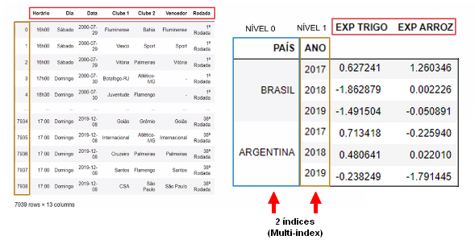

```python
import pandas as pd
import numpy as np
```

```python
lista = [ ['BRASIL','BRASIL','BRASIL','ARGENTINA','ARGENTINA','ARGENTINA'],[2017,2018,2019,2017,2018,2019] ]
```

```python
tuplas = zip(*lista)
```

A função zip 'junta' o 1º item da 1ª lista com o 1º item da 1ª lista... 2º item da 1ª lista com o 2º item da 2ª lista... e assim por diante.

```python
tuplas     #Chamando a tupla notamos que foi armazenado valor em endereço de memória.
```

```
<zip at 0x181d7870b48>
```

```python
tuplas = list(tuplas)  # Esse comando sim gera as tuplas em forma de lista formadas pelo zip.
```

```python
tuplas
```

```
[('BRASIL', 2017),
 ('BRASIL', 2018),
 ('BRASIL', 2019),
 ('ARGENTINA', 2017),
 ('ARGENTINA', 2018),
 ('ARGENTINA', 2019)]
```

```python
multi = pd.MultiIndex.from_tuples(tuplas)
```

Esse comando recebe como argumento o item que desejo transformar em Multi-índice, no caso é tupla ( from_tuples ). Agora o Python já entende que a variável multi possui vários níveis.

```python
multi
```

```
MultiIndex([(   'BRASIL', 2017),
            (   'BRASIL', 2018),
            (   'BRASIL', 2019),
            ('ARGENTINA', 2017),
            ('ARGENTINA', 2018),
            ('ARGENTINA', 2019)],
           )
```

```python
# Agora podemos criar o Dataframe
```

```python
df1 = pd.DataFrame(data = np.random.randn(6,2), index = multi, columns = ['EXP. TRIGO','EXP. ARROZ'] )
```

Entendendo a linha de comando:

pd.DataFrame - criação de um Dataframe a partir de parâmetros que serão inseridos;

data = np.random.randn(6,2) - Como não há valores, geramos através do Numpy, valores randômicos (6 linhas, 2 colunas);

index = multi - Os índices (multi-índices) provém da variável multi que foi criada;

columns = ['EXP. TRIGO','EXP. ARROZ'] - Nomeamos as duas colunas.

```python
df1
```

|  |  | EXP. TRIGO | EXP. ARROZ |
| --- | --- | --- | --- |
| BRASIL | 2017 | 0.627241 | 1.260346 |
|  | 2018 | -1.862879 | 0.002226 |
|  | 2019 | -1.491504 | -0.050891 |
| ARGENTINA | 2017 | 0.713418 | -0.225940 |
|  | 2018 | 0.480641 | 0.022010 |
|  | 2019 | -0.238249 | -1.791445 |

#### O dataframe criado possui 2 níveis de linha:

#### NÍVEL 0 que se refere a 'BRASIL'/'ARGENTINA' e;

#### NÍVEL 1 que se refere aos anos 2017,2018 e 2019.

```python
df1.index.names = ['PAÍS','ANO']
```

```python
df1
```

| PAÍS | ANO | EXP. TRIGO | EXP. ARROZ |
| --- | --- | --- | --- |
| BRASIL | 2017 | 0.627241 | 1.260346 |
|  | 2018 | -1.862879 | 0.002226 |
|  | 2019 | -1.491504 | -0.050891 |
| ARGENTINA | 2017 | 0.713418 | -0.225940 |
|  | 2018 | 0.480641 | 0.022010 |
|  | 2019 | -0.238249 | -1.791445 |

```python
# Encontrando valores
```

```python
df1['EXP. ARROZ']     # Dentro de colchetes são aceitos os nomes das COLUNAS
```

```
PAÍS       ANO
BRASIL     2017    1.260346
           2018    0.002226
           2019   -0.050891
ARGENTINA  2017   -0.225940
           2018    0.022010
           2019   -1.791445
Name: EXP. ARROZ, dtype: float64
```

```python
df1.loc['BRASIL']   #Para selecionar linhas usar a função .loc
```

| ANO | EXP. TRIGO | EXP. ARROZ |
| --- | --- | --- |
| 2017 | 0.627241 | 1.260346 |
| 2018 | -1.862879 | 0.002226 |
| 2019 | -1.491504 | -0.050891 |

#### No caso acima foram exibidos os valores relacionados aos anos referentes ao 'BRASIL' (linha de NÍVEL 0)

#### E se eu quisesse saber valores relacionados a um índice de NÍVEL 1 ? Usa-se uma função XS() que acessa outros níveis.

```python
df1.xs(2017,axis=0,level=1) # Acessou os valores de 2017 para ambos os países/ AXIS=0 significa LINHA
```

| PAÍS | EXP. TRIGO | EXP. ARROZ |
| --- | --- | --- |
| BRASIL | 0.627241 | 1.260346 |
| ARGENTINA | 0.713418 | -0.225940 |

#### Desejo saber o valor de EXP. TRIGO do BRASIL em 2018:

```python
df1.loc[('BRASIL',2018),('EXP. TRIGO')]
```

```
-1.8628793466853286
```

##### Explicando o código acima: Localize, as linhas "Brasil" e "2018" e a coluna "EXP TRIGO" aí ele retornará para você o valor correspondente.

```python
df1[0:4]  #Notação de linhas.... irá do índice zero ao índice 3... como já visto anteriormente
```

| PAÍS | ANO | EXP. TRIGO | EXP. ARROZ |
| --- | --- | --- | --- |
| BRASIL | 2017 | 0.627241 | 1.260346 |
|  | 2018 | -1.862879 | 0.002226 |
|  | 2019 | -1.491504 | -0.050891 |
| ARGENTINA | 2017 | 0.713418 | -0.225940 |

### Outra maneira de visualização: Utilização da função UNSTACK()

```python
df2 = df1.unstack()
```

```python
df2
```

| ANO PAÍS | EXP. TRIGO 2017 | EXP. TRIGO 2018 | EXP. TRIGO 2019 | EXP. ARROZ 2017 | EXP. ARROZ 2018 | EXP. ARROZ 2019 |
| --- | --- | --- | --- | --- | --- | --- |
| ARGENTINA | 0.713418 | 0.480641 | -0.238249 | -0.225940 | 0.022010 | -1.791445 |
| BRASIL | 0.627241 | -1.862879 | -1.491504 | 1.260346 | 0.002226 | -0.050891 |

#### Verificamos acima que agora as COLUNAS que possuem níveis

```python
df2['EXP. TRIGO']
```

| ANO PAÍS | 2017 | 2018 | 2019 |
| --- | --- | --- | --- |
| ARGENTINA | 0.713418 | 0.480641 | -0.238249 |
| BRASIL | 0.627241 | -1.862879 | -1.491504 |

```python
df2.xs(2017,axis=1,level=1)  # acessar valores de 2017, que está em uma coluna (AXIS=1) e está no NÍVEL 1 (level=1)
```

| PAÍS | EXP. TRIGO | EXP. ARROZ |
| --- | --- | --- |
| ARGENTINA | 0.713418 | -0.225940 |
| BRASIL | 0.627241 | 1.260346 |

```python
df2.loc[('BRASIL'),('EXP. TRIGO',2018)]     # Como no exemplo anterior: Desejo saber o valor de EXP. TRIGO do BRASIL em 2018:
```

```
-1.8628793466853286
```

# AULA 18

### Unindo Dataframes ( Merge, Join, Concatenate )

- Concatenate

Mais utilizado/apropriado para concatenar LINHAS.

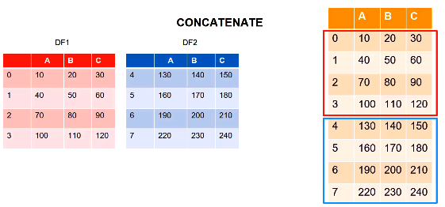

- Merge / Join

Mais apropriado para concatenar COLUNAS.

Essas funções possuem um atributo chamado HOW que especifica como a função irá concatenar:

- LEFT (à esquerda)
- INNER (internamente)
- OUTER (externamente)
- RIGHT (à direita)

##### Merge/Join utilizando LEFT

O Dataframe da esquerda compara suas chaves com o Dataframe da direita e se forem comuns as colunas dos valores serão concatenadas --- da esquerda para a direita.

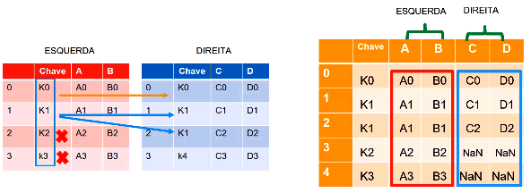

##### Merge/Join utilizando RIGHT

O Dataframe da direita compara suas chaves com o Dataframe da esquerda e se forem comuns as colunas dos valores serão concatenadas --- da direita para a esquerda.

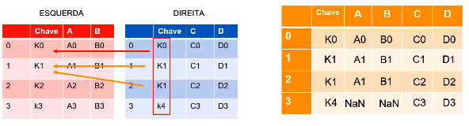

##### Merge/Join utilizando OUTER

O Dataframe resultante irá colocar as chaves dos Dataframe da esquerda e da direita eirá verificar a correspondência de cada um e aquilo que não tiver correspondência será indicado o valor nulo.

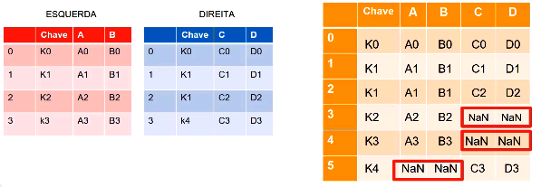

##### Merge/Join utilizando INNER

Basicamente é o contrário do OUTER. Nesse atributo somente o que existe em comum nos dois Dataframes será considerado.

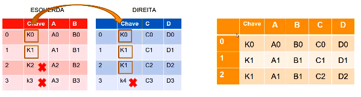

```python
import pandas as pd
import numpy as np
np.random.seed(100)
```

```python
df1 = pd.DataFrame( {'A': ['A0', 'A1', 'A2', 'A3'],
                     'B': ['B0', 'B1', 'B2', 'B3'],
                     'C': ['C0', 'C1', 'C2', 'C3'],
                     'D': ['D0', 'D1', 'D2', 'D3']},
                     index = [0, 1, 2, 3])

df2 = pd.DataFrame( {'A': ['A4', 'A5', 'A6', 'A7'],
                     'B': ['B4', 'B5', 'B6', 'B7'],
                     'C': ['C4', 'C5', 'C6', 'C7'],
                     'D': ['D4', 'D5', 'D6', 'D7']},
                     index = [4, 5, 6, 7])

df3 = pd.DataFrame( {'A': ['A8', 'A9', 'A10', 'A11'],
                     'B': ['B8', 'B9', 'B10', 'B11'],
                     'C': ['C8', 'C9', 'C10', 'C11'],
                     'D': ['D8', 'D9', 'D10', 'D11']},
                     index = [8, 9, 10, 11])
```

```python
dicionario = {'ID':[10, 11, 12, 13,14,], 'NOME':['Mario', 'Joana','Claudia', 'Lucas','Gabriel'],
              'CIDADE':['SÃO PAULO', 'RIO DE JANEIRO', 'SÃO PAULO', 'CAMPINAS', 'PORTO ALEGRE']}
dicionario2 = {'ID':[16, 11, 12, 13, 18,], 'Experiência':['Junior', 'Senior', 'Pleno', 'Estagiário', 'Analista']}

df4 = pd.DataFrame(data=dicionario)
df5 = pd.DataFrame(data=dicionario2)
```

```python
 df1
```

|  | A | B | C | D |
| --- | --- | --- | --- | --- |
| 0 | A0 | B0 | C0 | D0 |
| 1 | A1 | B1 | C1 | D1 |
| 2 | A2 | B2 | C2 | D2 |
| 3 | A3 | B3 | C3 | D3 |

```python
df2
```

|  | A | B | C | D |
| --- | --- | --- | --- | --- |
| 4 | A4 | B4 | C4 | D4 |
| 5 | A5 | B5 | C5 | D5 |
| 6 | A6 | B6 | C6 | D6 |
| 7 | A7 | B7 | C7 | D7 |

```python
df3
```

|  | A | B | C | D |
| --- | --- | --- | --- | --- |
| 8 | A8 | B8 | C8 | D8 |
| 9 | A9 | B9 | C9 | D9 |
| 10 | A10 | B10 | C10 | D10 |
| 11 | A11 | B11 | C11 | D11 |

#### Usando a função de CONCATENAR:

```python
df_concat = pd.concat( [df1,df2] )  # PRECISA DOS COLCHETES !!!
```

```python
df_concat
```

|  | A | B | C | D |
| --- | --- | --- | --- | --- |
| 0 | A0 | B0 | C0 | D0 |
| 1 | A1 | B1 | C1 | D1 |
| 2 | A2 | B2 | C2 | D2 |
| 3 | A3 | B3 | C3 | D3 |
| 4 | A4 | B4 | C4 | D4 |
| 5 | A5 | B5 | C5 | D5 |
| 6 | A6 | B6 | C6 | D6 |
| 7 | A7 | B7 | C7 | D7 |

```python
df_concat = pd.concat( [df1,df2,df3] )
```

```python
df_concat
```

|  | A | B | C | D |
| --- | --- | --- | --- | --- |
| 0 | A0 | B0 | C0 | D0 |
| 1 | A1 | B1 | C1 | D1 |
| 2 | A2 | B2 | C2 | D2 |
| 3 | A3 | B3 | C3 | D3 |
| 4 | A4 | B4 | C4 | D4 |
| 5 | A5 | B5 | C5 | D5 |
| 6 | A6 | B6 | C6 | D6 |
| 7 | A7 | B7 | C7 | D7 |
| 8 | A8 | B8 | C8 | D8 |
| 9 | A9 | B9 | C9 | D9 |
| 10 | A10 | B10 | C10 | D10 |
| 11 | A11 | B11 | C11 | D11 |

#### Como dissemos concatenar no sentido das colunas não é apropriado com essa função, vejamos abaixo o motivo:

```python
df_concat = pd.concat([df1,df2], axis=1)
```

```python
df_concat     # Aparece um monte de NaN e os valores numéricos ficam expressos diagonalmente!
```

|  | A | B | C | D | A | B | C | D |
| --- | --- | --- | --- | --- | --- | --- | --- | --- |
| 0 | A0 | B0 | C0 | D0 | NaN | NaN | NaN | NaN |
| 1 | A1 | B1 | C1 | D1 | NaN | NaN | NaN | NaN |
| 2 | A2 | B2 | C2 | D2 | NaN | NaN | NaN | NaN |
| 3 | A3 | B3 | C3 | D3 | NaN | NaN | NaN | NaN |
| 4 | NaN | NaN | NaN | NaN | A4 | B4 | C4 | D4 |
| 5 | NaN | NaN | NaN | NaN | A5 | B5 | C5 | D5 |
| 6 | NaN | NaN | NaN | NaN | A6 | B6 | C6 | D6 |
| 7 | NaN | NaN | NaN | NaN | A7 | B7 | C7 | D7 |

#### Usando a função MERGE:

```python
df4
```

|  | ID | NOME | CIDADE |
| --- | --- | --- | --- |
| 0 | 10 | Mario | SÃO PAULO |
| 1 | 11 | Joana | RIO DE JANEIRO |
| 2 | 12 | Claudia | SÃO PAULO |
| 3 | 13 | Lucas | CAMPINAS |
| 4 | 14 | Gabriel | PORTO ALEGRE |

```python
df5
```

|  | ID | Experiência |
| --- | --- | --- |
| 0 | 16 | Junior |
| 1 | 11 | Senior |
| 2 | 12 | Pleno |
| 3 | 13 | Estagiário |
| 4 | 18 | Analista |

- MERGE ( INNER )

```python
merge_inner = pd.merge(df4,df5)        # NÃO precisei especificar o modo INNER do merge porque já é o padrão inicial da função
```

```python
merge_inner
```

|  | ID | NOME | CIDADE | Experiência |
| --- | --- | --- | --- | --- |
| 0 | 11 | Joana | RIO DE JANEIRO | Senior |
| 1 | 12 | Claudia | SÃO PAULO | Pleno |
| 2 | 13 | Lucas | CAMPINAS | Estagiário |

- MERGE ( OUTER )

```python
merge_outer = pd.merge(df4,df5, how='outer')
```

```python
merge_outer
```

|  | ID | NOME | CIDADE | Experiência |
| --- | --- | --- | --- | --- |
| 0 | 10 | Mario | SÃO PAULO | NaN |
| 1 | 11 | Joana | RIO DE JANEIRO | Senior |
| 2 | 12 | Claudia | SÃO PAULO | Pleno |
| 3 | 13 | Lucas | CAMPINAS | Estagiário |
| 4 | 14 | Gabriel | PORTO ALEGRE | NaN |
| 5 | 16 | NaN | NaN | Junior |
| 6 | 18 | NaN | NaN | Analista |

- MERGE ( LEFT )

```python
merge_left = pd.merge(df4,df5, how='left')
```

```python
merge_left
```

|  | ID | NOME | CIDADE | Experiência |
| --- | --- | --- | --- | --- |
| 0 | 10 | Mario | SÃO PAULO | NaN |
| 1 | 11 | Joana | RIO DE JANEIRO | Senior |
| 2 | 12 | Claudia | SÃO PAULO | Pleno |
| 3 | 13 | Lucas | CAMPINAS | Estagiário |
| 4 | 14 | Gabriel | PORTO ALEGRE | NaN |

- MERGE ( RIGHT )

```python
merge_right = pd.merge(df4,df5, how='right')
```

```python
merge_right
```

|  | ID | NOME | CIDADE | Experiência |
| --- | --- | --- | --- | --- |
| 0 | 11 | Joana | RIO DE JANEIRO | Senior |
| 1 | 12 | Claudia | SÃO PAULO | Pleno |
| 2 | 13 | Lucas | CAMPINAS | Estagiário |
| 3 | 16 | NaN | NaN | Junior |
| 4 | 18 | NaN | NaN | Analista |

### Diferença entre o MERGE e o JOIN

#### CASO JOIN

- O Join é utilizado para unir Dataframes através de SEUS ÍNDICES (iguais entre eles), se houver colunas com o mesmo nome entre os dois Dataframes ocorrerá um erro e será necessário incluir sufixos para as duas colunas que possuem nomes iguais para que o comando funcione. Nos Dataframes abaixo existe uma coluna em comum, a coluna 'ID'

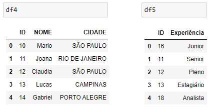

Se fizermos: join_esquerda = df4.join(df5) irá dar erro por causa das colunas iguais então devemos fazer como se segue abaixo:

```python
join_esquerda = df4.join(df5, lsuffix='_x', rsuffix='_y')
```

lsuffix (sufixo do df da esquerda) e rsuffix (sufixo do df da direita) irão acrescentar termos nas colunas que são iguais nos dois df´s

Os termos _x e _y serão acrescentados nas colunas para diferenciá-las e as duas colunas serão mostradas, o que não é legal !

```python
join_esquerda
```

|  | IDx | NOME | CIDADE | IDy | Experiência |
| --- | --- | --- | --- | --- | --- |
| 0 | 10 | Mario | SÃO PAULO | 16 | Junior |
| 1 | 11 | Joana | RIO DE JANEIRO | 11 | Senior |
| 2 | 12 | Claudia | SÃO PAULO | 12 | Pleno |
| 3 | 13 | Lucas | CAMPINAS | 13 | Estagiário |
| 4 | 14 | Gabriel | PORTO ALEGRE | 18 | Analista |

```python
dicionario3 = {'NOME':['Mario', 'Joana','Claudia', 'Lucas','Gabriel'],
              'CIDADE':['SÃO PAULO', 'RIO DE JANEIRO', 'SÃO PAULO', 'CAMPINAS', 'PORTO ALEGRE']}
dicionario4 = {'Experiência':['Junior', 'Senior', 'Pleno', 'Estagiário', 'Analista']}

df7 = pd.DataFrame(data=dicionario3)
df8 = pd.DataFrame(data=dicionario4)
```

```python
df7
```

|  | NOME | CIDADE |
| --- | --- | --- |
| 0 | Mario | SÃO PAULO |
| 1 | Joana | RIO DE JANEIRO |
| 2 | Claudia | SÃO PAULO |
| 3 | Lucas | CAMPINAS |
| 4 | Gabriel | PORTO ALEGRE |

```python
df8
```

|  | Experiência |
| --- | --- |
| 0 | Junior |
| 1 | Senior |
| 2 | Pleno |
| 3 | Estagiário |
| 4 | Analista |

Acima temos dois df em que não existem colunas em comum e APENAS OS ÍNDICES coincidem.

- O JOIN É APROPRIADO NESSES CASOS !

```python
join_esquerda2 = df7.join(df8)
```

```python
join_esquerda2
```

|  | NOME | CIDADE | Experiência |
| --- | --- | --- | --- |
| 0 | Mario | SÃO PAULO | Junior |
| 1 | Joana | RIO DE JANEIRO | Senior |
| 2 | Claudia | SÃO PAULO | Pleno |
| 3 | Lucas | CAMPINAS | Estagiário |
| 4 | Gabriel | PORTO ALEGRE | Analista |

#### CASO MERGE

- O MERGE é utilizado para quando queremos unir Dataframes em que EXISTAM COLUNAS COMUNS entre eles. Ocorre erro se os df´s não possuírem alguma coluna em comum.

Nos Dataframes abaixo o MERGE funcionária (Coluna 'ID' em ambos):

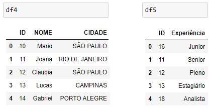

Já nos Dataframes abaixo, que não possuem colunas em comum, o MERGE NÃO FUNCIONARIA ( daria erro ):

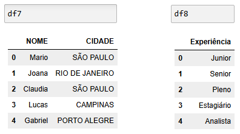

# AULA 19

### Grouby Dataframes

- Agrupar dados de alguma forma específica

```python
import pandas as pd
import numpy as np
```

```python
data = {'Sede':['SP','SP','MG','MG','RJ','RJ','ES','ES'],
       'Vendedor':['Jorge','Ana','Tiago','Pedro','Raphaela','Guto','Maria','Carolina'],
       'Vendas':[2000,2500,3100,1200,1500,3900,2900,3900]}
df = pd.DataFrame(data)
```

```python
df
```

|  | Sede | Vendedor | Vendas |
| --- | --- | --- | --- |
| 0 | SP | Jorge | 2000 |
| 1 | SP | Ana | 2500 |
| 2 | MG | Tiago | 3100 |
| 3 | MG | Pedro | 1200 |
| 4 | RJ | Raphaela | 1500 |
| 5 | RJ | Guto | 3900 |
| 6 | ES | Maria | 2900 |
| 7 | ES | Carolina | 3900 |

```python
by_sede = df.groupby('Sede')  #Agrupe esse dataframe por Sede
```

```python
by_sede.max() # Qual foi as sedes que venderam mais:
```

| Sede | Vendedor | Vendas |
| --- | --- | --- |
| ES | Maria | 3900 |
| MG | Tiago | 3100 |
| RJ | Raphaela | 3900 |
| SP | Jorge | 2500 |

```python
by_sede.mean() # Retorne a média por sede desse df agrupado
```

| Sede | Vendas |
| --- | --- |
| ES | 3400 |
| MG | 2150 |
| RJ | 2700 |
| SP | 2250 |

```python
by_sede.describe() # Dados estatísticos para o df agrupado
```

| Sede | Vendas count | Vendas mean | Vendas std | Vendas min | Vendas 25% | Vendas 50% | Vendas 75% | Vendas max |
| --- | --- | --- | --- | --- | --- | --- | --- | --- |
| ES | 2.0 | 3400.0 | 707.106781 | 2900.0 | 3150.0 | 3400.0 | 3650.0 | 3900.0 |
| MG | 2.0 | 2150.0 | 1343.502884 | 1200.0 | 1675.0 | 2150.0 | 2625.0 | 3100.0 |
| RJ | 2.0 | 2700.0 | 1697.056275 | 1500.0 | 2100.0 | 2700.0 | 3300.0 | 3900.0 |
| SP | 2.0 | 2250.0 | 353.553391 | 2000.0 | 2125.0 | 2250.0 | 2375.0 | 2500.0 |

```python
by_sede.describe().transpose() # Inverte a tabela anterior (O que era linha vira coluna e o que era coluna vira linha)
```

|  | Sede | ES | MG | RJ | SP |
| --- | --- | --- | --- | --- | --- |
| Vendas | count | 2.000000 | 2.000000 | 2.000000 | 2.000000 |
|  | mean | 3400.000000 | 2150.000000 | 2700.000000 | 2250.000000 |
|  | std | 707.106781 | 1343.502884 | 1697.056275 | 353.553391 |
|  | min | 2900.000000 | 1200.000000 | 1500.000000 | 2000.000000 |
|  | 25% | 3150.000000 | 1675.000000 | 2100.000000 | 2125.000000 |
|  | 50% | 3400.000000 | 2150.000000 | 2700.000000 | 2250.000000 |
|  | 75% | 3650.000000 | 2625.000000 | 3300.000000 | 2375.000000 |
|  | max | 3900.000000 | 3100.000000 | 3900.000000 | 2500.000000 |

```python
by_sede.describe().transpose()['SP'] # Mostra os dados da tabela anterior só para o estado de SP
```

```
Vendas  count       2.000000
        mean     2250.000000
        std       353.553391
        min      2000.000000
        25%      2125.000000
        50%      2250.000000
        75%      2375.000000
        max      2500.000000
Name: SP, dtype: float64
```

#### Agrupando Dataframes Multi-Index

```python
arrays = [['São Paulo', 'São Paulo', 'Rio de Janeiro', 'Rio de Janeiro','Minas Gerais','Minas Gerais'],
['Garrafas','Copos','Garrafas','Copos','Garrafas','Copos' ]]
index = pd.MultiIndex.from_arrays(arrays, names=('Estado', 'Produto'))
df1 = pd.DataFrame({'Total Vendido R$': [10000, 35000, 22400, 12890,10880,13900]},index=index)
```

```python
df1
```

| Estado | Produto | Total Vendido R$ |
| --- | --- | --- |
| São Paulo | Garrafas | 10000 |
|  | Copos | 35000 |
| Rio de Janeiro | Garrafas | 22400 |
|  | Copos | 12890 |
| Minas Gerais | Garrafas | 10880 |
|  | Copos | 13900 |

```python
multi_byestado = df1.groupby('Estado',level=0)
```

Agrupar o df1 por 'Estado' e é preciso indicar que 'Estado está no level 0 dos índices

```python
multi_byestado
```

```
<pandas.core.groupby.generic.DataFrameGroupBy object at 0x00000268EA5F5848>
```

```python
multi_byestado.mean()
```

| Estado | Total Vendido R$ |
| --- | --- |
| Minas Gerais | 12390 |
| Rio de Janeiro | 17645 |
| São Paulo | 22500 |

```python
multi_byestado.max()
```

| Estado | Total Vendido R$ |
| --- | --- |
| Minas Gerais | 13900 |
| Rio de Janeiro | 22400 |
| São Paulo | 35000 |

```python
multi_byproduto = df1.groupby('Produto', level=1)
```

```python
multi_byproduto.mean()
```

| Produto | Total Vendido R$ |
| --- | --- |
| Copos | 20596.666667 |
| Garrafas | 14426.666667 |

# AULA 20

### Funções do Pandas

```python
import pandas as pd
import numpy as np
```

```python
df = pd.read_csv('campeonato-brasileiro-full.csv')
```

```python
df
```

|  | Horário | Dia | Data | Clube 1 | Clube 2 | Vencedor | Rodada | Arena | Clube 1 Gols | Clube 2 Gols | Clube 1 Estado | Clube 2 Estado | Estado Clube Vencedor |
| --- | --- | --- | --- | --- | --- | --- | --- | --- | --- | --- | --- | --- | --- |
| 0 | 16h00 | Sábado | 2000-07-29 | Fluminense | Bahia | Fluminense | 1ª Rodada | Maracanã | 2 | 0 | RJ | BA | RJ |
| 1 | 16h00 | Sábado | 2000-07-29 | Vasco | Sport | Sport | 1ª Rodada | São Januário | 0 | 2 | RJ | PE | PE |
| 2 | 16h00 | Sábado | 2000-07-29 | Vitória | Palmeiras | Vitória | 1ª Rodada | Barradão | 4 | 1 | ES | SP | ES |
| 3 | 17h00 | Domingo | 2000-07-30 | Botafogo-RJ | Atlético-MG | - | 1ª Rodada | Caio Martins | 0 | 0 | RJ | MG | Empate |
| 4 | 18h30 | Domingo | 2000-07-30 | Juventude | Flamengo | - | 1ª Rodada | Alfredo Jaconi | 1 | 1 | RS | RJ | Empate |
| ... | ... | ... | ... | ... | ... | ... | ... | ... | ... | ... | ... | ... | ... |
| 7934 | 17:00 | Domingo | 2019-12-08 | Goiás | Grêmio | Goiás | 38ª Rodada | Serra Dourada | 3 | 2 | GO | RS | GO |
| 7935 | 17:00 | Domingo | 2019-12-08 | Internacional | Atlético-MG | Internacional | 38ª Rodada | Beira Rio | 2 | 1 | RS | MG | RS |
| 7936 | 17:00 | Domingo | 2019-12-08 | Cruzeiro | Palmeiras | Palmeiras | 38ª Rodada | Mineirão | 0 | 2 | MG | SP | SP |
| 7937 | 17:00 | Domingo | 2019-12-08 | Santos | Flamengo | Santos | 38ª Rodada | Vila Belmiro | 4 | 0 | SP | RJ | SP |
| 7938 | 17:00 | Domingo | 2019-12-08 | CSA | São Paulo | São Paulo | 38ª Rodada | Rei Pelé | 1 | 2 | AL | SP | SP |

7939 rows × 13 columns

```python
df.head()
```

|  | Horário | Dia | Data | Clube 1 | Clube 2 | Vencedor | Rodada | Arena | Clube 1 Gols | Clube 2 Gols | Clube 1 Estado | Clube 2 Estado | Estado Clube Vencedor |
| --- | --- | --- | --- | --- | --- | --- | --- | --- | --- | --- | --- | --- | --- |
| 0 | 16h00 | Sábado | 2000-07-29 | Fluminense | Bahia | Fluminense | 1ª Rodada | Maracanã | 2 | 0 | RJ | BA | RJ |
| 1 | 16h00 | Sábado | 2000-07-29 | Vasco | Sport | Sport | 1ª Rodada | São Januário | 0 | 2 | RJ | PE | PE |
| 2 | 16h00 | Sábado | 2000-07-29 | Vitória | Palmeiras | Vitória | 1ª Rodada | Barradão | 4 | 1 | ES | SP | ES |
| 3 | 17h00 | Domingo | 2000-07-30 | Botafogo-RJ | Atlético-MG | - | 1ª Rodada | Caio Martins | 0 | 0 | RJ | MG | Empate |
| 4 | 18h30 | Domingo | 2000-07-30 | Juventude | Flamengo | - | 1ª Rodada | Alfredo Jaconi | 1 | 1 | RS | RJ | Empate |

```python
df.info()
```

```
<class 'pandas.core.frame.DataFrame'>
RangeIndex: 7939 entries, 0 to 7938
Data columns (total 13 columns):
 #   Column                 Non-Null Count  Dtype
---  ------                 --------------  -----
 0   Horário                7582 non-null   object
 1   Dia                    7939 non-null   object
 2   Data                   7939 non-null   object
 3   Clube 1                7939 non-null   object
 4   Clube 2                7939 non-null   object
 5   Vencedor               7939 non-null   object
 6   Rodada                 7939 non-null   object
 7   Arena                  7939 non-null   object
 8   Clube 1 Gols           7939 non-null   int64
 9   Clube 2 Gols           7939 non-null   int64
 10  Clube 1 Estado         7939 non-null   object
 11  Clube 2 Estado         7939 non-null   object
 12  Estado Clube Vencedor  7939 non-null   object
dtypes: int64(2), object(11)
memory usage: 806.4+ KB
```

```python
df['Data'].min()
```

```
'2000-07-29'
```

```python
df['Data'].max()
```

```
'2019-12-08'
```

- Qual foi a média de gols de todos os jogos do time mandande ( Clube 1 ) ? (No período em que o dataframe abrange que é de 2000 a 2019)

```python
df['Clube 1 Gols'].mean()
```

```
1.5968006046101524
```

```python
df['Clube 2 Gols'].mean() # Média de gols do visitante no período de 2000 a 2019
```

```
1.0525255069908048
```

- E se desejarmos saber a média do TOTAL de gols ? Total = [Clube 1 Gols] + [Clube 2 Gols]

Precisamos CRIAR essa nova coluna de valores:

```python
df['Total de Gols'] = df['Clube 1 Gols'] + df['Clube 2 Gols']
```

A coluna foi criada:

```python
df.head()
```

|  | Horário | Dia | Data | Clube 1 | Clube 2 | Vencedor | Rodada | Arena | Clube 1 Gols | Clube 2 Gols | Clube 1 Estado | Clube 2 Estado | Estado Clube Vencedor | Total de Gols |
| --- | --- | --- | --- | --- | --- | --- | --- | --- | --- | --- | --- | --- | --- | --- |
| 0 | 16h00 | Sábado | 2000-07-29 | Fluminense | Bahia | Fluminense | 1ª Rodada | Maracanã | 2 | 0 | RJ | BA | RJ | 2 |
| 1 | 16h00 | Sábado | 2000-07-29 | Vasco | Sport | Sport | 1ª Rodada | São Januário | 0 | 2 | RJ | PE | PE | 2 |
| 2 | 16h00 | Sábado | 2000-07-29 | Vitória | Palmeiras | Vitória | 1ª Rodada | Barradão | 4 | 1 | ES | SP | ES | 5 |
| 3 | 17h00 | Domingo | 2000-07-30 | Botafogo-RJ | Atlético-MG | - | 1ª Rodada | Caio Martins | 0 | 0 | RJ | MG | Empate | 0 |
| 4 | 18h30 | Domingo | 2000-07-30 | Juventude | Flamengo | - | 1ª Rodada | Alfredo Jaconi | 1 | 1 | RS | RJ | Empate | 2 |

Assim, podemos agora calcular a média do total de gols das partidas:

```python
df['Total de Gols'].mean()
```

```
2.649326111600957
```

```python
# Qual foi o time que mais venceu ?
```

```python
df['Vencedor'].value_counts()
```

```
-                  2040
São Paulo           348
Cruzeiro            322
Santos              319
Grêmio              308
Internacional       302
Flamengo            298
Corinthians         293
Athlético-PR        291
Fluminense          288
Atlético-MG         282
Palmeiras           279
Vasco               216
Goiás               214
Botafogo-RJ         205
Coritiba            187
Vitória             152
Figueirense         151
Ponte Preta         149
Sport               127
Bahia               123
Paraná              104
São Caetano         103
Juventude            96
Chapecoense          69
Guarani              63
Portuguesa           57
Avaí                 57
Náutico              54
Fortaleza            51
Criciúma             50
Paysandu             50
Ceará                40
Atlético-GO          39
América-MG           38
Botafogo-rj          26
Santa Cruz           25
Gama                 21
Barueri              12
Santo André          11
Brasiliense          10
Ipatinga              9
CSA                   8
Joinville             7
Grêmio Prudente       7
Botafogo-SP           6
SANTOS                6
CRUZEIRO              4
América-RN            4
FLUMINENSE            4
VASCO                 4
CORINTHIANS           3
SPORT                 2
FLAMENGO              1
PALMEIRAS             1
INTERNACIONAL         1
PONTE PRETA           1
portuguesa            1
Name: Vencedor, dtype: int64
```

- De acordo com o exibido vemos que São Paulo, seguido de Cruzeiro e Santos foram os clubes que mais venceram no campeonato entre os anos de 2000 a 2019.
- PORÉM nota-se que no final da lista ocorre a repetição de clubes, porém, estes estão com letras maiúsculas. É PRECISO deixar o nome dos clubes TODOS NO MESMO FORMATO para uma análise geral correta:

```python
df['Vencedor'] = df['Vencedor'].str.upper()
```

A função str.upper() irá percorrer os valores string (str) da coluna vencedor e alterar tudo pra maiúsculo (upper).

```python
df['Vencedor']  # Agora TODOS os clubes estão com a letra maiúscula e assim podemos avaliar corretamente quem mais venceu
```

```
0          FLUMINENSE
1               SPORT
2             VITÓRIA
3                   -
4                   -
            ...
7934            GOIÁS
7935    INTERNACIONAL
7936        PALMEIRAS
7937           SANTOS
7938        SÃO PAULO
Name: Vencedor, Length: 7939, dtype: object
```

```python
df['Vencedor'].value_counts()
```

```
-                  2040
SÃO PAULO           348
CRUZEIRO            326
SANTOS              325
GRÊMIO              308
INTERNACIONAL       303
FLAMENGO            299
CORINTHIANS         296
FLUMINENSE          292
ATHLÉTICO-PR        291
ATLÉTICO-MG         282
PALMEIRAS           280
BOTAFOGO-RJ         231
VASCO               220
GOIÁS               214
CORITIBA            187
VITÓRIA             152
FIGUEIRENSE         151
PONTE PRETA         150
SPORT               129
BAHIA               123
PARANÁ              104
SÃO CAETANO         103
JUVENTUDE            96
CHAPECOENSE          69
GUARANI              63
PORTUGUESA           58
AVAÍ                 57
NÁUTICO              54
FORTALEZA            51
CRICIÚMA             50
PAYSANDU             50
CEARÁ                40
ATLÉTICO-GO          39
AMÉRICA-MG           38
SANTA CRUZ           25
GAMA                 21
BARUERI              12
SANTO ANDRÉ          11
BRASILIENSE          10
IPATINGA              9
CSA                   8
JOINVILLE             7
GRÊMIO PRUDENTE       7
BOTAFOGO-SP           6
AMÉRICA-RN            4
Name: Vencedor, dtype: int64
```

```python
df['Vencedor'].value_counts().head()
```

```
-            2040
SÃO PAULO     348
CRUZEIRO      326
SANTOS        325
GRÊMIO        308
Name: Vencedor, dtype: int64
```

```python
# Qual o estado com maior número de vitórias ?
```

```python
df['Estado Clube Vencedor'].value_counts()
```

```
Empate    2040
SP        1659
RJ        1042
RS         707
MG         655
PR         582
SC         334
GO         253
PE         208
ES         152
BA         123
CE          91
PA          50
DF          31
AL           8
RN           4
Name: Estado Clube Vencedor, dtype: int64
```

#### Função sort_values() - Ordena os valores

- Qual o maior número de gols que um clube mandante fez no período ?

Utilizamos a função sort_values(), porém por padrão a função vem configurada para mostrar do menor pro maior, então para mostrar do maior pro menos precisamos colocar no argumento: ascending = False

```python
df.sort_values(by = 'Clube 1 Gols', ascending = False)
```

|  | Horário | Dia | Data | Clube 1 | Clube 2 | Vencedor | Rodada | Arena | Clube 1 Gols | Clube 2 Gols | Clube 1 Estado | Clube 2 Estado | Estado Clube Vencedor | Total de Gols |
| --- | --- | --- | --- | --- | --- | --- | --- | --- | --- | --- | --- | --- | --- | --- |
| 693 | 16h00 | Domingo | 2001-11-25 | Vasco | São Paulo | VASCO | 26ª Rodada | São Januário | 7 | 1 | RJ | SP | RJ | 8 |
| 1122 | 16h00 | Domingo | 2003-04-27 | Goiás | Juventude | GOIÁS | 6ª Rodada | Serra Dourada | 7 | 0 | GO | RS | GO | 7 |
| 1992 | 20h30 | Terça-feira | 2004-09-28 | São Paulo | Paysandu | SÃO PAULO | 33ª Rodada | Morumbi | 7 | 0 | SP | PA | SP | 7 |
| 2309 | 21h45 | Quarta-feira | 2005-07-27 | Athlético-PR | Vasco | ATHLÉTICO-PR | 15ª Rodada | Arena da Baixada | 7 | 2 | PR | RJ | PR | 9 |
| 357 | 14h30 | Domingo | 2001-08-05 | Vasco | Guarani | VASCO | 2ª Rodada | São Januário | 7 | 1 | RJ | SP | RJ | 8 |
| ... | ... | ... | ... | ... | ... | ... | ... | ... | ... | ... | ... | ... | ... | ... |
| 6365 | 18h00 | Domingo | 2015-11-01 | Vasco | Fluminense | FLUMINENSE | 33ª Rodada | Engenhão | 0 | 1 | RJ | RJ | RJ | 1 |
| 6364 | 17h00 | Domingo | 2015-11-01 | Atlético-MG | Corinthians | CORINTHIANS | 33ª Rodada | Independência | 0 | 3 | MG | SP | SP | 3 |
| 6363 | 17h00 | Domingo | 2015-11-01 | Chapecoense | Athlético-PR | - | 33ª Rodada | Arena Condá | 0 | 0 | SC | PR | Empate | 0 |
| 4253 | 16h00 | Domingo | 2010-08-01 | Internacional | Grêmio | - | 12ª Rodada | Beira Rio | 0 | 0 | RS | RS | Empate | 0 |
| 2956 | 20h30 | Quinta-feira | 2006-11-09 | Fluminense | Ponte Preta | - | 34ª Rodada | Maracanã | 0 | 0 | RJ | SP | Empate | 0 |

7939 rows × 14 columns

#### - Função unique() - Pega os valores únicos desse Dataframe (coluna)

```python
df['Clube 1'] = df['Clube 1'].str.upper()
```

```python
df['Clube 1'].unique()  # Todos os valores únicos na coluna 'Clube 1', ou seja, todos os times presentes nessa coluna.
```

```
array(['FLUMINENSE', 'VASCO', 'VITÓRIA', 'BOTAFOGO-RJ', 'JUVENTUDE',
       'GUARANI', 'CRUZEIRO', 'AMÉRICA-MG', 'GOIÁS', 'CORITIBA', 'BAHIA',
       'FLAMENGO', 'GAMA', 'INTERNACIONAL', 'PONTE PRETA', 'SANTOS',
       'PALMEIRAS', 'ATHLÉTICO-PR', 'CORINTHIANS', 'ATLÉTICO-MG',
       'PORTUGUESA', 'GRÊMIO', 'SÃO PAULO', 'SANTA CRUZ', 'SPORT',
       'PARANÁ', 'REMO', 'SÃO CAETANO', 'MALUTROM', 'BOTAFOGO-SP',
       'FIGUEIRENSE', 'PAYSANDU', 'FORTALEZA', 'CRICIÚMA', 'BRASILIENSE',
       'AMÉRICA-RN', 'NÁUTICO', 'IPATINGA', 'AVAÍ', 'SANTO ANDRÉ',
       'BARUERI', 'ATLÉTICO-GO', 'CEARÁ', 'GRÊMIO PRUDENTE',
       'CHAPECOENSE', 'JOINVILLE', 'CSA'], dtype=object)
```

```python
df['Clube 2'] = df['Clube 2'].str.upper()
```

```python
df['Clube 2'].unique()  # Todos os valores únicos na coluna 'Clube 2', ou seja, todos os times presentes nessa coluna.
```

```
array(['BAHIA', 'SPORT', 'PALMEIRAS', 'ATLÉTICO-MG', 'FLAMENGO',
       'SANTA CRUZ', 'ATHLÉTICO-PR', 'GAMA', 'CORINTHIANS', 'GRÊMIO',
       'FLUMINENSE', 'GOIÁS', 'AMÉRICA-MG', 'VITÓRIA', 'BOTAFOGO-RJ',
       'SANTOS', 'CRUZEIRO', 'PONTE PRETA', 'GUARANI', 'SÃO PAULO',
       'PORTUGUESA', 'CORITIBA', 'INTERNACIONAL', 'JUVENTUDE', 'VASCO',
       'PARANÁ', 'MALUTROM', 'SÃO CAETANO', 'REMO', 'BOTAFOGO-SP',
       'PAYSANDU', 'FIGUEIRENSE', 'FORTALEZA', 'CRICIÚMA', 'BRASILIENSE',
       'NÁUTICO', 'AMÉRICA-RN', 'IPATINGA', 'BARUERI', 'AVAÍ',
       'SANTO ANDRÉ', 'GRÊMIO PRUDENTE', 'ATLÉTICO-GO', 'CEARÁ',
       'CHAPECOENSE', 'JOINVILLE', 'CSA'], dtype=object)
```

#### - Função nunique() - Ao invés de mostrar um array com os nomes dos valores únicos esta função mostra a QUANTIDADE de valores únicos.

```python
df['Clube 1'].nunique()
```

```
47
```

```python
df['Clube 2'].nunique()
```

```
47
```

```python
# Quais foram as maiores goleadas no período ?
```

Queremos um dataframe em que a coluna 'Clube 1 Gols' do df apresente os valores iguais ao valor máximo atingido por essa coluna:

```python
df[df['Clube 1 Gols'] == df['Clube 1 Gols'].max()]
```

|  | Horário | Dia | Data | Clube 1 | Clube 2 | Vencedor | Rodada | Arena | Clube 1 Gols | Clube 2 Gols | Clube 1 Estado | Clube 2 Estado | Estado Clube Vencedor | Total de Gols |
| --- | --- | --- | --- | --- | --- | --- | --- | --- | --- | --- | --- | --- | --- | --- |
| 357 | 14h30 | Domingo | 2001-08-05 | VASCO | GUARANI | VASCO | 2ª Rodada | São Januário | 7 | 1 | RJ | SP | RJ | 8 |
| 693 | 16h00 | Domingo | 2001-11-25 | VASCO | SÃO PAULO | VASCO | 26ª Rodada | São Januário | 7 | 1 | RJ | SP | RJ | 8 |
| 1122 | 16h00 | Domingo | 2003-04-27 | GOIÁS | JUVENTUDE | GOIÁS | 6ª Rodada | Serra Dourada | 7 | 0 | GO | RS | GO | 7 |
| 1671 | 16h00 | Domingo | 2004-05-16 | CRICIÚMA | GOIÁS | CRICIÚMA | 6ª Rodada | Heriberto Hulse | 7 | 2 | SC | GO | SC | 9 |
| 1992 | 20h30 | Terça-feira | 2004-09-28 | SÃO PAULO | PAYSANDU | SÃO PAULO | 33ª Rodada | Morumbi | 7 | 0 | SP | PA | SP | 7 |
| 2055 | 20h30 | Quarta-feira | 2004-10-27 | FLUMINENSE | JUVENTUDE | FLUMINENSE | 38ª Rodada | Raulino de Oliveira | 7 | 1 | RJ | RS | RJ | 8 |
| 2309 | 21h45 | Quarta-feira | 2005-07-27 | ATHLÉTICO-PR | VASCO | ATHLÉTICO-PR | 15ª Rodada | Arena da Baixada | 7 | 2 | PR | RJ | PR | 9 |
| 2557 | 16h00 | Domingo | 2005-11-06 | CORINTHIANS | SANTOS | CORINTHIANS | 37ª Rodada | Pacaembu | 7 | 1 | SP | SP | SP | 8 |

```python
df[df['Clube 2 Gols'] == df['Clube 2 Gols'].max()]
```

|  | Horário | Dia | Data | Clube 1 | Clube 2 | Vencedor | Rodada | Arena | Clube 1 Gols | Clube 2 Gols | Clube 1 Estado | Clube 2 Estado | Estado Clube Vencedor | Total de Gols |
| --- | --- | --- | --- | --- | --- | --- | --- | --- | --- | --- | --- | --- | --- | --- |
| 1501 | 21h40 | Quarta-feira | 2003-10-22 | BAHIA | SANTOS | SANTOS | 38ª Rodada | Fonte Nova | 4 | 7 | BH | SP | SP | 11 |
| 1600 | 16h00 | Domingo | 2003-12-14 | BAHIA | CRUZEIRO | CRUZEIRO | 46ª Rodada | Fonte Nova | 0 | 7 | BH | MG | MG | 7 |
| 3498 | 20h30 | Quinta-feira | 2008-07-17 | FIGUEIRENSE | GRÊMIO | GRÊMIO | 14ª Rodada | Orlando Scarpelli | 1 | 7 | SC | RS | RS | 8 |

```python
# Qual foram os 5 times que fizeram mais gols no campeonato brasileiro entre os anos 2000 e 2019 ?
```

```python
by_clube1 = df.groupby('Clube 1')
```

```python
by_clube1['Clube 1 Gols'].sum().sort_values(ascending = False).head()
# Quero a soma da coluna 'Clube 1 Gols' do Dataframe (que foi agrupado no passo anterior), de forma decrescente (5 primeiros).
```

```
Clube 1
SANTOS          701
CRUZEIRO        668
SÃO PAULO       663
ATLÉTICO-MG     620
ATHLÉTICO-PR    618
Name: Clube 1 Gols, dtype: int64
```